# R-demo-1.R

### Graphical data summaries

```r
x <- cars$speed; x
```

```
##  [1]  4  4  7  7  8  9 10 10 10 11 11 12 12 12 12 13 13 13 13 14 14 14 14
## [24] 15 15 15 16 16 17 17 17 18 18 18 18 19 19 19 20 20 20 20 20 22 23 24
## [47] 24 24 24 25
```

```r
y <- cars$dist; y
```

```
##  [1]   2  10   4  22  16  10  18  26  34  17  28  14  20  24  28  26  34
## [18]  34  46  26  36  60  80  20  26  54  32  40  32  40  50  42  56  76
## [35]  84  36  46  68  32  48  52  56  64  66  54  70  92  93 120  85
```

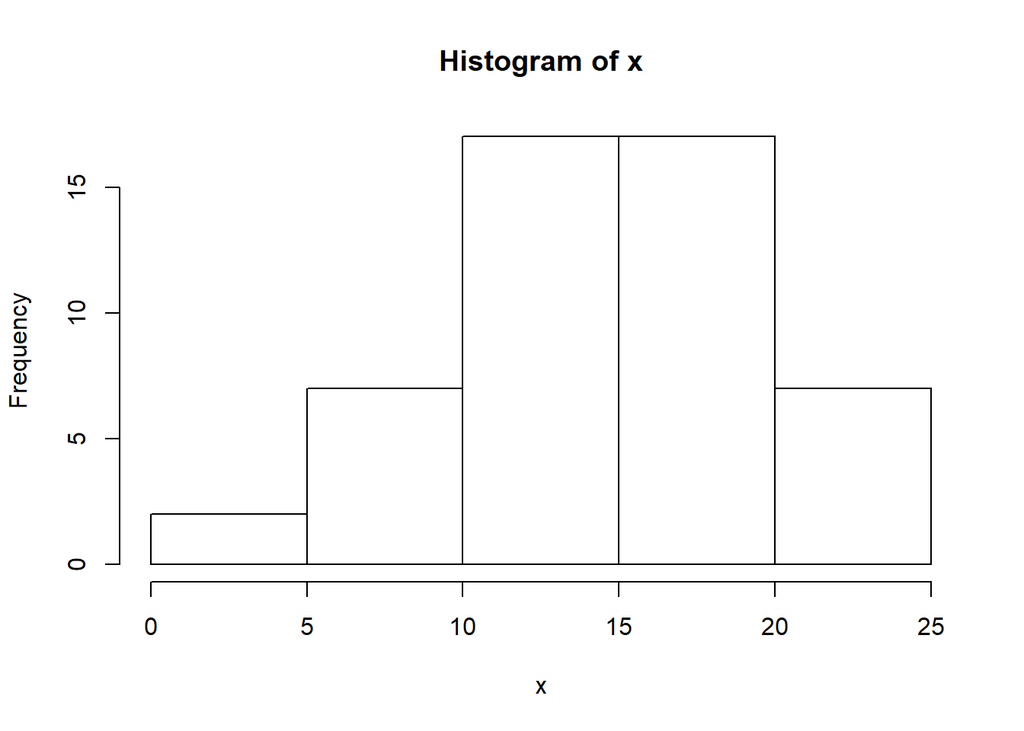

```r
hist(x)  # histogram
```

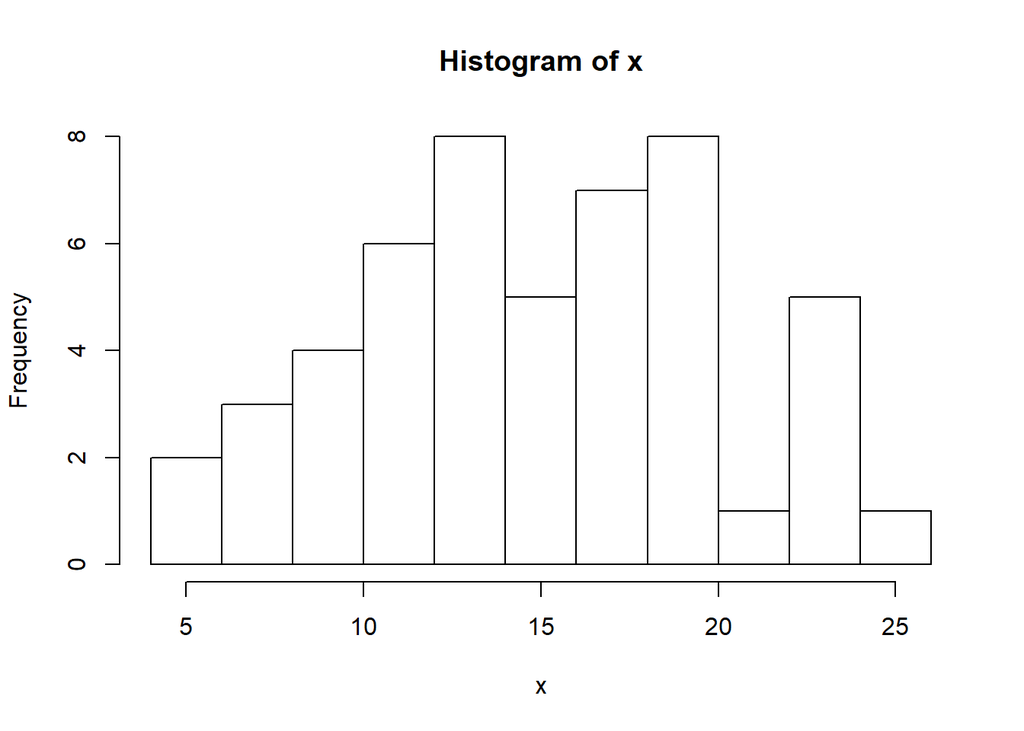

```r
hist(x, breaks=10)  # good for getting an overview of data
```

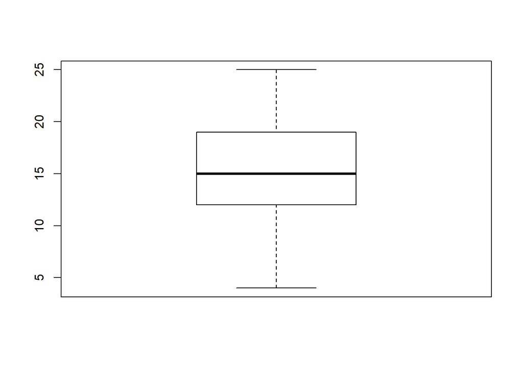

```r
boxplot(x)  # boxplot contains 25,50,75 % quantiles, and whiskers
```

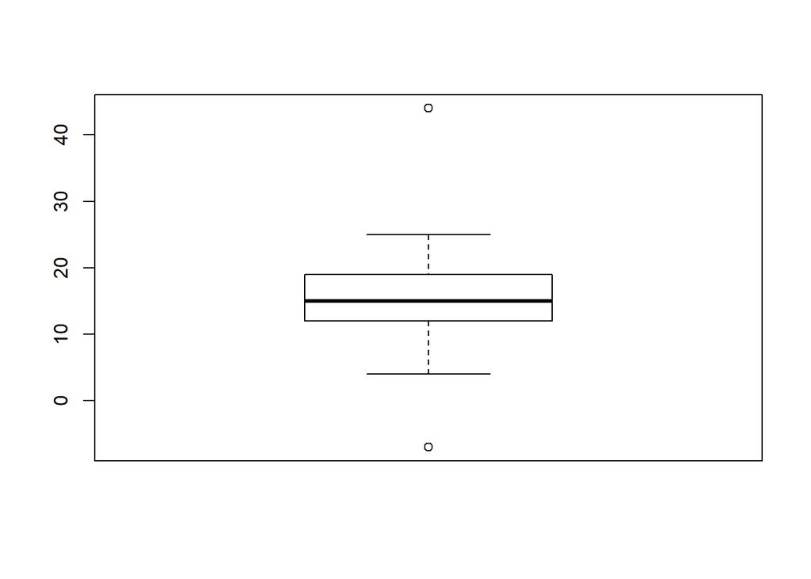

```r
boxplot(c(x, -7, 4, 44))  # changing data a bit - boxplot reveals potential outliers
```

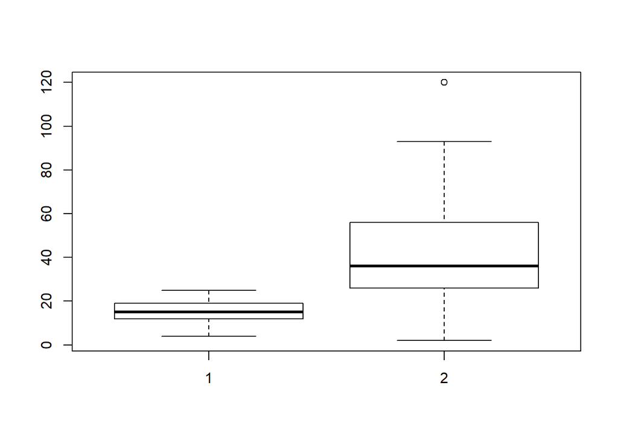

```r
boxplot(x, y)  # good for comparing data (here it is of course meaningless)
```

### Numerical data-summaries

```r
mean(x)  # average
```

```
## [1] 15.4
```

```r
median(x)  # median
```

```
## [1] 15
```

```r
var(x)  # variance
```

```
## [1] 27.95918
```

```r
sd(x)  # standard deviation
```

```
## [1] 5.287644
```

```r
range(x)  # range
```

```
## [1]  4 25
```

```r
quantile(x)  # quantiles
```

```
##   0%  25%  50%  75% 100%
##    4   12   15   19   25
```

```r
summary(x)  # can be used for most objects in R
```

```
##    Min. 1st Qu.  Median    Mean 3rd Qu.    Max.
##     4.0    12.0    15.0    15.4    19.0    25.0
```

### Clean-up

```r
rm(list=ls())
```

## Exercises for PART 2

## Exercise I

1. Consider the built-in dataset airquality, and find out what it contains.
2. Try to plot the whole dataframe, and see what you get.
3. Make a scatterplot of the ozone as a function of the temperature.
4. Make a nicer plot by adding labels to the x and y axes, and a title on top of the plot. (hint: check the help for plot.default and note that text goes within “”)
5. Make a plot zoomed in on the x-values 70-80 (hing: same help page).
6. Try `plot(airquality$Ozone)`. What does it do? Change the scatter plot to a plot joining the measurements with line segments. (hint: check the argument type in the help page for plot (not plot.default))
7. Make a histogram and a boxplot of the Ozone level.

## Exercise II

1. Read the data `data3.dat` using `read.table`. (note: this file contains names of each column, so you need to find out how to import headers)
2. Make some plots to investigate the data, as well as some non-graphical summaries.

## PART 3: distributions in R

R can be used for calculating density functions and distribution functions of most known distributions

```r
dnorm(1, mean=0, sd=1)  # density function for normal dist. with mean 0 and sd 1 evaluated at 1
```

```
## [1] 0.2419707
```

```r
pnorm(1, mean=0, sd=1)  # Corresponding distribution function
```

```
## [1] 0.8413447
```

let’s plot them - the `curve` function is useful for plotting mathematical functions in R

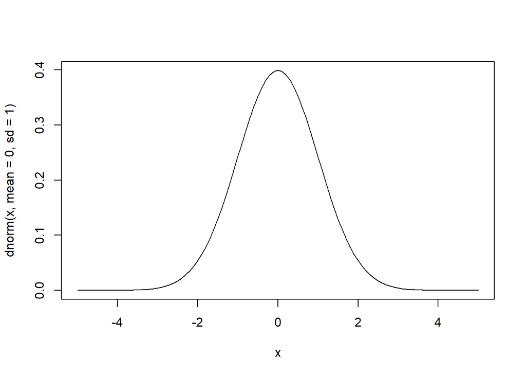

```r
curve(dnorm(x, mean=0, sd=1), from=-5, to=5)  # x must be called x in curve
```

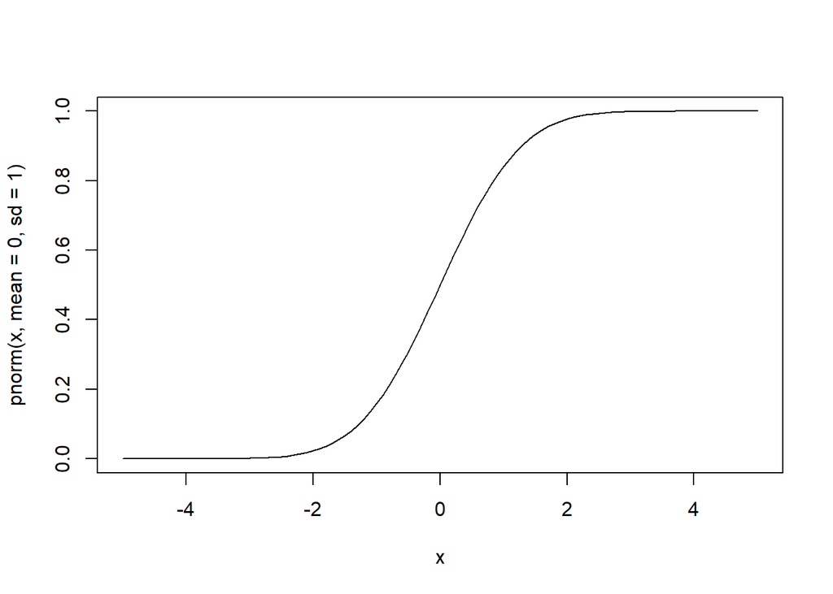

```r
curve(pnorm(x, mean=0, sd=1), from=-5, to=5)
```

the inverse distribution function (quantile function)

```r
qnorm(0.8, mean=0, sd=1)
```

```
## [1] 0.8416212
```

R can also simulate the distributions

```r
rnorm(5, mean=0, sd=1)  # 5 simulations
```

```
## [1] -0.56516741 -0.96987833 -1.18556542  1.09189994  0.07673905
```

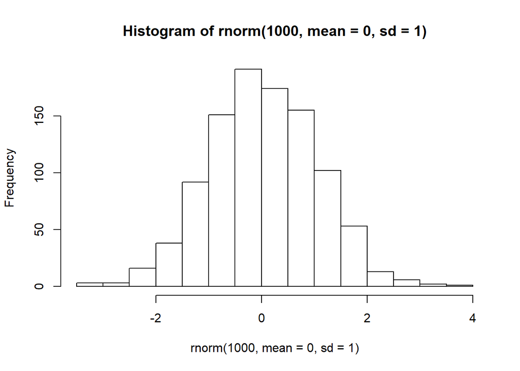

```r
hist(rnorm(1000, mean=0, sd=1))  # histogram of 1000 simulations
```

Functions for handling distributions come with the following naming convention:  
First part:  
`d` = **D**ensity function  
`p` = distribution function (cumulative **P**robability)  
`q` = inverse distribution function (**Q**uantile)  
`r` = simulate (**R**andom number generator)  
Last part: distribution name, e.g:  
`norm` = normal  
`exp` = exponential  
`gamma` = gamma  
`t` = t  
`binom` = binomial  
etc.

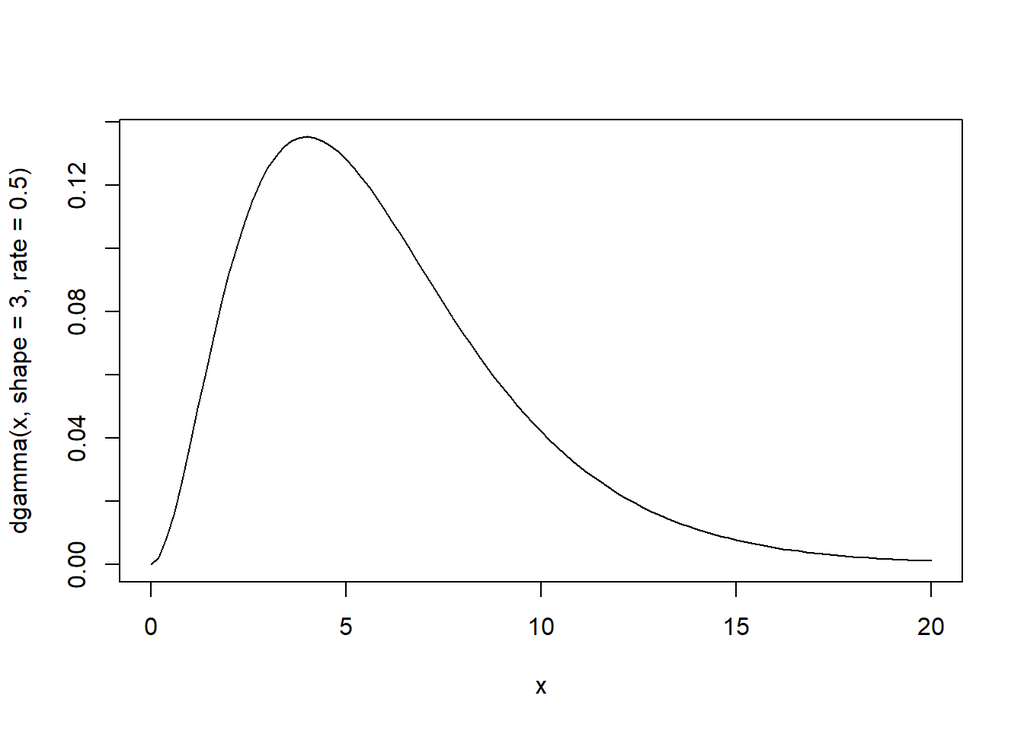

```r
curve(dgamma(x, shape = 3, rate = 0.5), from=0, to=20)
```

### Clean-up

```r
rm(list=ls())
```

## Exercises for PART 3

## Exercise I

1. Plot the density and distribution function for the t distribution with 3 degree of freedom.
2. Make 50 simulations of this t-distribution, and make a histogram. Can you see that this is not a standard normal distribution? (hint: the `curve` command has an argument `add=TRUE` that allows you to add a plot on top of the histogram – try to add the normal density to the plot; note that this requires the histogram to integrate to one, which can be achieved by including the argument `probability=TRUE` to the `hist` command)
3. Repeat exercise b with 10 degrees of freedom - can you still see that this is not a standard normal distribution?

## Exercise II

1. The uniform distribution can be simulated using `runif()` - try it out.
2. In your probability course you have probably learned how to simulate random variables using the inversion method (i.e. taking the inverse cumulative distribution funciton of the wanted distribution, and evaluating this at a uniform random value). For the exponential distribution this is done by calculating -log(1-U)/lambda, where U is a uniform random variable and lambda is the rate parameters of the exponential distribution. Use this for simulating a number of exponential random variables.